# Bayesian Rugby

I came across the following blog post on http://danielweitzenfeld.github.io/passtheroc/blog/2014/10/28/bayes-premier-league/ I quote from him, about his realization about Premier League Football - _It occurred to me that this problem is perfect for a Bayesian model. We want to infer the latent paremeters (every team's strength) that are generating the data we observe (the scorelines). Moreover, we know that the scorelines are a noisy measurement of team strength, so ideally, we want a model that makes it easy to quantify our uncertainty about the underlying strengths.

*So I googled 'Bayesian football' and found this paper, called 'Bayesian hierarchical model for the prediction of football results.' The authors (Gianluca Baio and Marta A. Blangiardo) being Italian, though, the 'football' here is soccer.*

*In this post, I'm going to reproduce the first model described in the paper using pymc. While they used Seria A in their paper, I'm going to use the 2013-2014 Premier League.*

Since I am a rugby fan I decide to apply the results of the paper Bayesian Football to the Six Nations.

## Acquiring the data

The first step was to acquire the data - which I created in a csv file from data I got on wikipedia and sports websites. To be honest a lot of this turned out to be manual entry. But this is fine for T=6 teams :)

We largely follow the code of the website cited above, with only a few small changes. We do less wrangling because I personally curated the data.

```python
%matplotlib inline
%config InlineBackend.figure_format = 'retina'
```

```python
import os
import math
import warnings
warnings.filterwarnings('ignore')

from IPython.display import Image, HTML
import numpy as np
import pandas as pd
import seaborn as sns
import matplotlib.pyplot as plt
import pymc # I know folks are switching to "as pm" but I'm just not there yet
```

```python
DATA_DIR = os.path.join(os.getcwd(), 'data/')
```

Now that we've set the right path, we import the data from a csv file and inspect it.

```python
data_file = DATA_DIR + 'results_2014.csv'
df = pd.read_csv(data_file, sep=',')
df.head()
```

|  | home_team | away_team | home_score | away_score |
| --- | --- | --- | --- | --- |
| 0 | Wales | Italy | 23 | 15 |
| 1 | France | England | 26 | 24 |
| 2 | Ireland | Scotland | 28 | 6 |
| 3 | Ireland | Wales | 26 | 3 |
| 4 | Scotland | England | 0 | 20 |

Like the tutorial I create an integer for the teams. I tried doing this a different way but this turned out to be the most efficient method

```python
teams = df.home_team.unique()
teams = pd.DataFrame(teams, columns=['team'])
teams['i'] = teams.index
teams.head()
```

|  | team | i |
| --- | --- | --- |
| 0 | Wales | 0 |
| 1 | France | 1 |
| 2 | Ireland | 2 |
| 3 | Scotland | 3 |
| 4 | Italy | 4 |

```python
teams
```

|  | team | i |
| --- | --- | --- |
| 0 | Wales | 0 |
| 1 | France | 1 |
| 2 | Ireland | 2 |
| 3 | Scotland | 3 |
| 4 | Italy | 4 |
| 5 | England | 5 |

Now that we have inspected the teams we can go through the 'merging' phase or 'joining'

```python
df = pd.merge(df, teams, left_on='home_team', right_on='team', how='left')
df = df.rename(columns = {'i': 'i_home'}).drop('team', 1)
df = pd.merge(df, teams, left_on='away_team', right_on='team', how='left')
df = df.rename(columns = {'i': 'i_away'}).drop('team', 1)
df.head()
```

|  | home_team | away_team | home_score | away_score | i_home | i_away |
| --- | --- | --- | --- | --- | --- | --- |
| 0 | Wales | Italy | 23 | 15 | 0 | 4 |
| 1 | France | England | 26 | 24 | 1 | 5 |
| 2 | Ireland | Scotland | 28 | 6 | 2 | 3 |
| 3 | Ireland | Wales | 26 | 3 | 2 | 0 |
| 4 | Scotland | England | 0 | 20 | 3 | 5 |

```python
observed_home_goals = df.home_score.values
observed_away_goals = df.away_score.values
home_team = df.i_home.values
away_team = df.i_away.values
num_teams = len(df.i_home.drop_duplicates())
num_games = len(home_team)
```

Now, that we've extracted the data into arrays, so that pymc can work with it. Note that each of the arrays (observed_home_goals, observed_away_goals, home_team, away_team) are the same length, and that the ith entry of each refers to the same game - we can do some sanity checks. A simple one is 'what is the num of teams'?

```python
num_teams
```

```
6
```

```python
df
```

|  | home_team | away_team | home_score | away_score | i_home | i_away |
| --- | --- | --- | --- | --- | --- | --- |
| 0 | Wales | Italy | 23 | 15 | 0 | 4 |
| 1 | France | England | 26 | 24 | 1 | 5 |
| 2 | Ireland | Scotland | 28 | 6 | 2 | 3 |
| 3 | Ireland | Wales | 26 | 3 | 2 | 0 |
| 4 | Scotland | England | 0 | 20 | 3 | 5 |
| 5 | France | Italy | 30 | 10 | 1 | 4 |
| 6 | Wales | France | 27 | 6 | 0 | 1 |
| 7 | Italy | Scotland | 20 | 21 | 4 | 3 |
| 8 | England | Ireland | 13 | 10 | 5 | 2 |
| 9 | Ireland | Italy | 46 | 7 | 2 | 4 |
| 10 | Scotland | France | 17 | 19 | 3 | 1 |
| 11 | England | Wales | 29 | 18 | 5 | 0 |
| 12 | Italy | England | 11 | 52 | 4 | 5 |
| 13 | Wales | Scotland | 51 | 3 | 0 | 3 |
| 14 | France | Ireland | 20 | 22 | 1 | 2 |

Now we do some transformation of the scores - I find when it comes to fitting such data to Bayesian models this is a decent step.

```python
g = df.groupby('i_away')
att_starting_points = np.log(g.away_score.mean())
g = df.groupby('i_home')
def_starting_points = -np.log(g.away_score.mean())
```

# The model.

The league is made up by a total of T= 6 teams, playing each other once in a season. We indicate the number of points scored by the home and the away team in the g-th game of the season (15 games) as $y_{g1}$ and $y_{g2}$ respectively.

The vector of observed counts $\mathbb{y} = (y_{g1}, y_{g2})$ is modelled as independent Poisson: $y_{gi}| \theta_{gj} \tilde\;\; Poisson(\theta_{gj})$ where the theta parameters represent the scoring intensity in the g-th game for the team playing at home (j=1) and away (j=2), respectively.

We model these parameters according to a formulation that has been used widely in the statistical literature, assuming a log-linear random effect model: $$log \theta_{g1} = home + att_{h(g)} + def_{a(g)} $$ $$log \theta_{g2} = att_{a(g)} + def_{h(g)}$$ the parameter home represents the advantage for the team hosting the game and we assume that this effect is constant for all the teams and throughout the season. In addition, the scoring intensity is determined jointly by the attack and defense ability of the two teams involved, represented by the parameters att and def, respectively. In line with the Bayesian approach, we have to specify some suitable prior distributions for all the random parameters in our model. The variable $home$ is modelled as a fixed effect, assuming a standard flat prior distribution. We use the notation of describing the Normal distribution in terms of mean and the precision. $home \tilde\; Normal(0,0.0001)$

Conversely, for each t = 1, ..., T, the team-specific effects are modelled as exchangeable from a common distribution: $att_t \tilde\; Normal(\mu_{att}, \tau_{att})$ and $def_t \tilde\; Normal(\mu_{def}, \tau_{def})$

Note that they're breaking out team strength into attacking and defending strength. A negative defense parameter will sap the mojo from the opposing team's attacking parameter.

I made two tweaks to the model. It didn't make sense to me to have a $\mu_{att}$ when we're enforcing the sum-to-zero constraint by subtracting the mean anyway. So I eliminated $\mu_{att}$ and $\mu_{def}$

```python
#hyperpriors
home = pymc.Normal('home', 0, .0001, value=0)
tau_att = pymc.Gamma('tau_att', .1, .1, value=10)
tau_def = pymc.Gamma('tau_def', .1, .1, value=10)
intercept = pymc.Normal('intercept', 0, .0001, value=0)
```

```python
#team-specific parameters
atts_star = pymc.Normal("atts_star",
                        mu=0,
                        tau=tau_att,
                        size=num_teams,
                        value=att_starting_points.values)
defs_star = pymc.Normal("defs_star",
                        mu=0,
                        tau=tau_def,
                        size=num_teams,
                        value=def_starting_points.values)
```

```python
# trick to code the sum to zero contraint
@pymc.deterministic
def atts(atts_star=atts_star):
    atts = atts_star.copy()
    atts = atts - np.mean(atts_star)
    return atts

@pymc.deterministic
def defs(defs_star=defs_star):
    defs = defs_star.copy()
    defs = defs - np.mean(defs_star)
    return defs

@pymc.deterministic
def home_theta(home_team=home_team,
               away_team=away_team,
               home=home,
               atts=atts,
               defs=defs,
               intercept=intercept):
    return np.exp(intercept +
                  home +
                  atts[home_team] +
                  defs[away_team])

@pymc.deterministic
def away_theta(home_team=home_team,
               away_team=away_team,
               home=home,
               atts=atts,
               defs=defs,
               intercept=intercept):
    return np.exp(intercept +
                  atts[away_team] +
                  defs[home_team])


home_points = pymc.Poisson('home_points',
                          mu=home_theta,
                          value=observed_home_goals,
                          observed=True)
away_points = pymc.Poisson('away_points',
                          mu=away_theta,
                          value=observed_away_goals,
                          observed=True)

mcmc = pymc.MCMC([home, intercept, tau_att, tau_def,
                  home_theta, away_theta,
                  atts_star, defs_star, atts, defs,
                  home_points, away_points])
map_ = pymc.MAP( mcmc )
map_.fit()
mcmc.sample(200000, 40000, 20)
```

```
 [-----------------100%-----------------] 200000 of 200000 complete in 252.3 sec
```

# Diagnostics

We can see that it converges just like the model for the Premier League in the other tutorial.

I wonder and this is left as a question if all field sports have models of this form that converge.

```
Plotting home
```

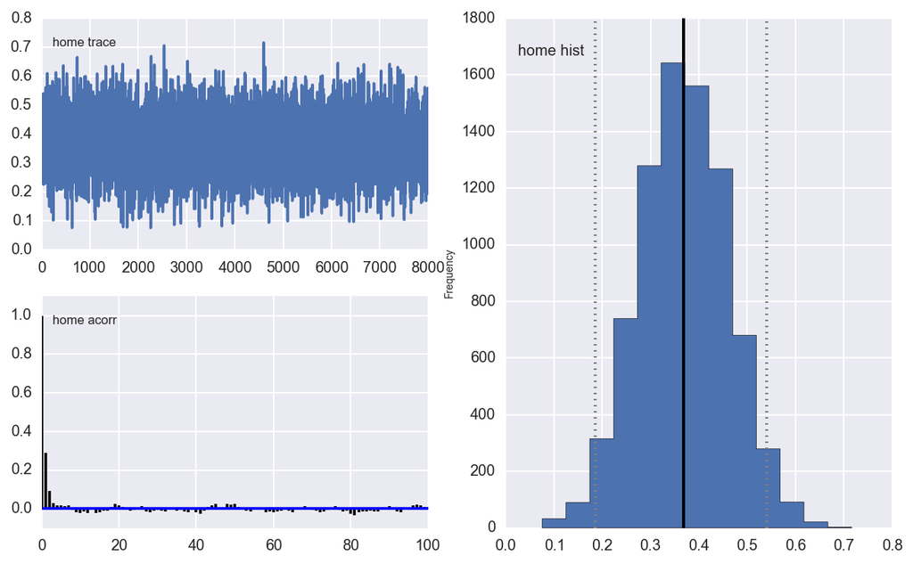

```python
pymc.Matplot.plot(home)
```

```
Plotting intercept
```

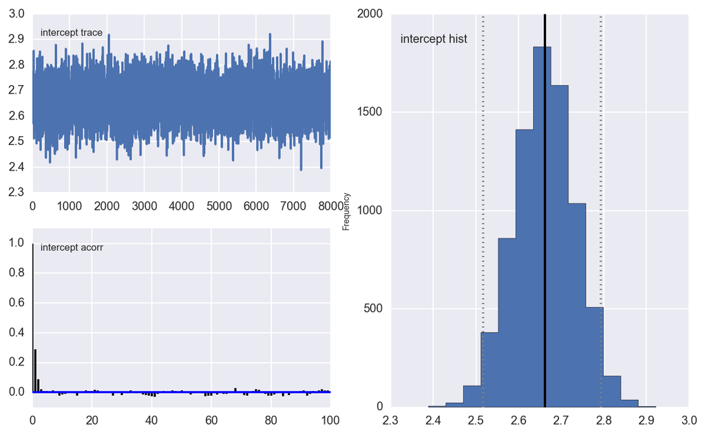

```python
pymc.Matplot.plot(intercept)
```

```
Plotting tau_att
```

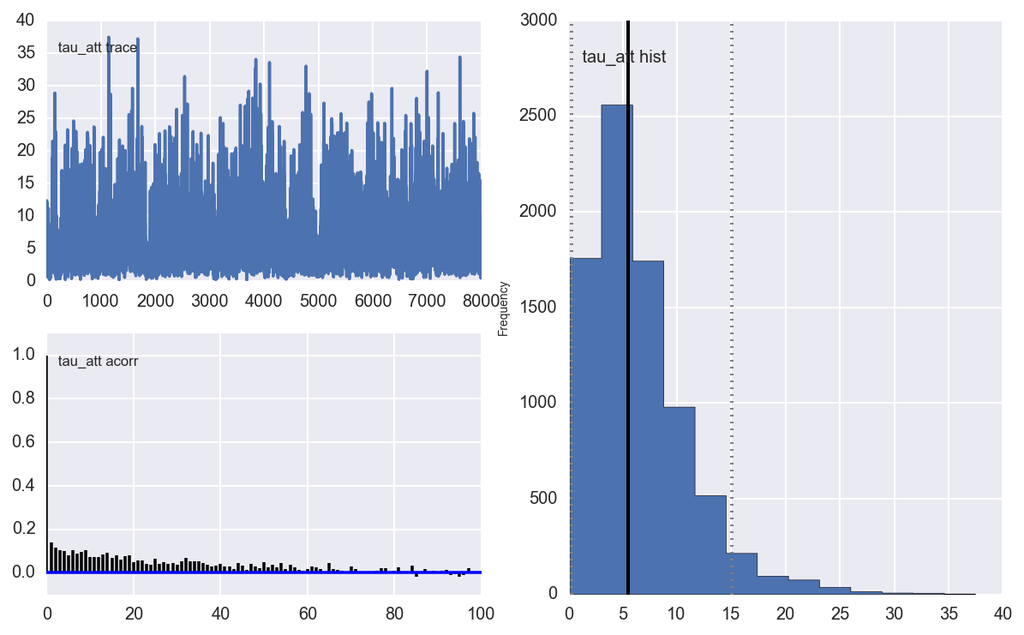

```python
pymc.Matplot.plot(tau_att)
```

```
Plotting tau_def
```

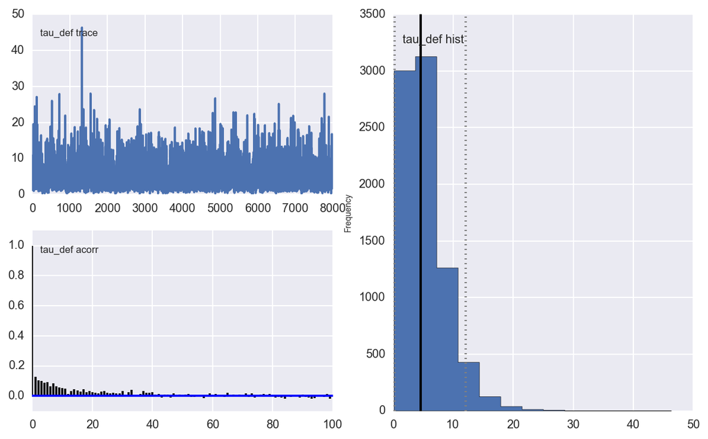

```python
pymc.Matplot.plot(tau_def)
```

It looks like we have decent parameters and that the intercept was a good idea. I'm not so sure about how autocorrelated the Tau terms are but that is for me me to brush up on my Bayesian models.